# Student Personas

## Section 1: Data Exploration

```r
library(readr)
library(dplyr)
```

```r
library(ggplot2)
library(caret)
library(cluster)
library(factoextra)
data <- read.csv("personas.csv")
summary(data)
```

```
##    Program            College               Age           Gender
##  Length:6627        Length:6627        Min.   :20.00   Length:6627
##  Class :character   Class :character   1st Qu.:25.00   Class :character
##  Mode  :character   Mode  :character   Median :29.00   Mode  :character
##                                        Mean   :30.72
##                                        3rd Qu.:35.00
##                                        Max.   :73.00
##    FirstGen             Race             TSI_MATH         TSI_WRITING
##  Length:6627        Length:6627        Length:6627        Length:6627
##  Class :character   Class :character   Class :character   Class :character
##  Mode  :character   Mode  :character   Mode  :character   Mode  :character
##
##
##
##  TSI_READING        MotherEducation    FatherEducation     Homeschooled
##  Length:6627        Length:6627        Length:6627        Min.   :0.000000
##  Class :character   Class :character   Class :character   1st Qu.:0.000000
##  Mode  :character   Mode  :character   Mode  :character   Median :0.000000
##                                                           Mean   :0.003622
##                                                           3rd Qu.:0.000000
##                                                           Max.   :1.000000
##      HasGED        Highschool           FinAid              EFC
##  Min.   :0.0000   Length:6627        Length:6627        Length:6627
##  1st Qu.:0.0000   Class :character   Class :character   Class :character
##  Median :0.0000   Mode  :character   Mode  :character   Mode  :character
##  Mean   :0.1067
##  3rd Qu.:0.0000
##  Max.   :1.0000
```

```r
str(data)
```

```
## 'data.frame':    6627 obs. of  16 variables:
##  $ Program        : chr  "Cosmetology" "Substance Abuse Counseling" "Organizational Management" "English" ...
##  $ College        : chr  "Career and Technical" "Health Science" "Business" "Language and Fine Arts" ...
##  $ Age            : int  24 34 34 26 23 25 22 28 31 30 ...
##  $ Gender         : chr  "Female" "Male" "Female" "Female" ...
##  $ FirstGen       : chr  "Unknown" "Unknown" "Unknown" "Yes" ...
##  $ Race           : chr  "White" "Hispanic/Latino" "White" "Black or African American" ...
##  $ TSI_MATH       : chr  "344" "26" "352" "341" ...
##  $ TSI_WRITING    : chr  "NULL" "94" "56" "355" ...
##  $ TSI_READING    : chr  "NULL" "90" "90" "350" ...
##  $ MotherEducation: chr  "Some College" "Unknown" "High School Diploma or GED" "Some High School" ...
##  $ FatherEducation: chr  "Some College" "Unknown" "Some College" "High School Diploma or GED" ...
##  $ Homeschooled   : int  0 0 0 0 0 0 0 0 0 0 ...
##  $ HasGED         : int  0 0 0 0 0 0 0 0 0 0 ...
##  $ Highschool     : chr  "MISD- LHS" "Midland High School" "MISD- LHS" "MISD- LHS" ...
##  $ FinAid         : chr  "OTHER" "FED PELL GRANT" "FED PELL GRANT" "FED PELL GRANT" ...
##  $ EFC            : chr  "616" "9999999" "0" "0" ...
```

### Feature description

**Program** - Student’s declared degree pathway - Categorical

**College** - The college division the student’s degree belongs to - Categorical

**Age** - The students age - Numerical

**Gender** - The students gender - Categorical

**FirstGen** - Indicates if the student is a first-generation college student in their family - Categorical

**Race** - The student’s ethnicity (‘Hispanic/Latino’ or other specified race) - Categorical

**TSI_MATH** - The student’s Texas Success Initiative Assessment score for Math - Numerical

**TSI_WRITING** - The student’s Texas Success Initiative Assessment score for Writing - Numerical

**TSI_READING** - The student’s Texas Success Initiative Assessment score for Reading - Numerical

**MotherEducation** - The highest level of education the student’s mother has attained - Categorical

**FatherEducation** - The highest level of education the student’s father has attained - Categorical

**Homeschooled** - Indicates if the student was homeschooled - Categorical **(0 - No, 1 - Yes)**

**HasGED** - Indicates if the student has their GED - Categorical **(0 - No, 1 - Yes)**

**Highschool** - The high school the student attended - Categorical

**FinAid** - The type of financial aid the student qualified for (‘Other’ or ‘Fed Pell Grant’) - Categorical

**EFC** - The Expected Family Contribution financially - Numerical

### Data exploration

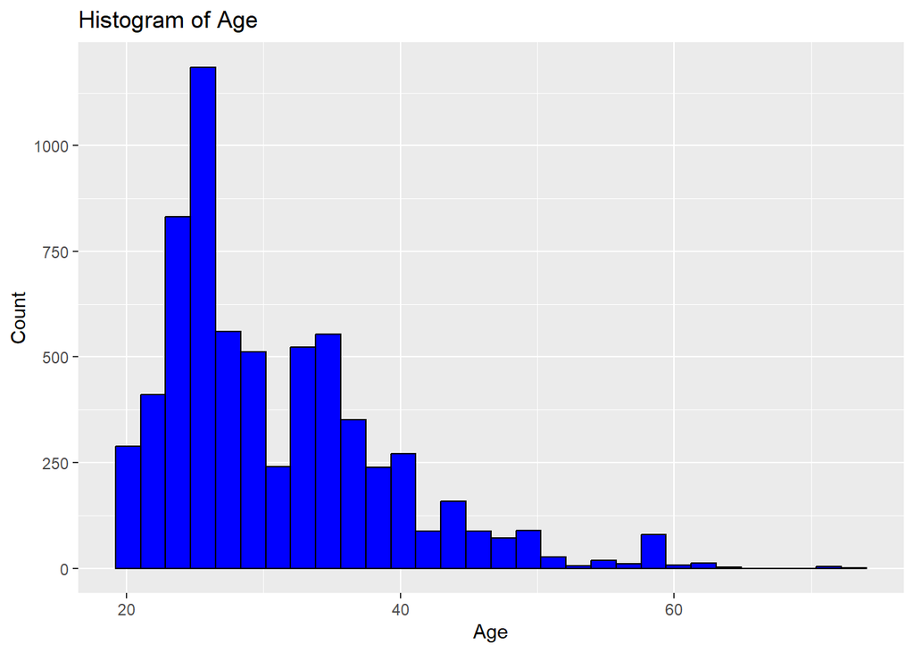

```r
# Age
ggplot(data, aes(x = Age)) +
  geom_histogram(bins = 30, fill = "blue", color = "black") +
  labs(title = "Histogram of Age", x = "Age", y = "Count")
```

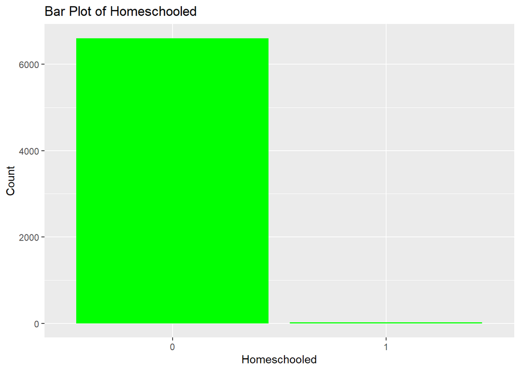

```r
# Homeschooled
ggplot(data, aes(x = factor(Homeschooled))) +
  geom_bar(fill = "green") +
  labs(title = "Bar Plot of Homeschooled", x = "Homeschooled", y = "Count")
```

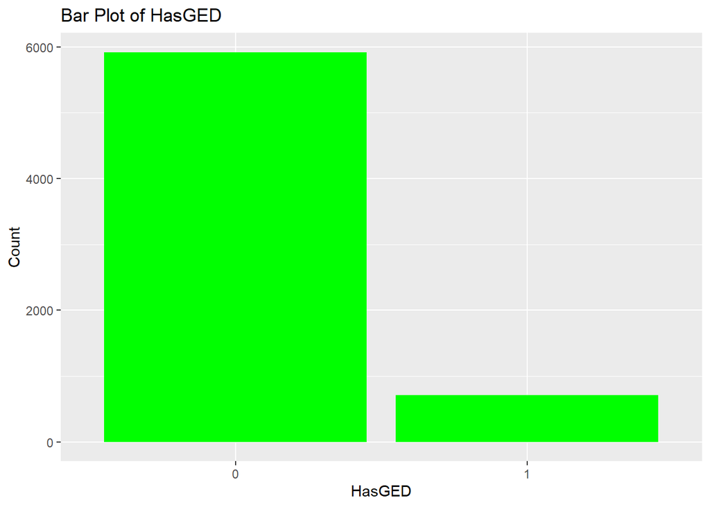

```r
# HasGED
ggplot(data, aes(x = factor(HasGED))) +
  geom_bar(fill = "green") +
  labs(title = "Bar Plot of HasGED", x = "HasGED", y = "Count")
```

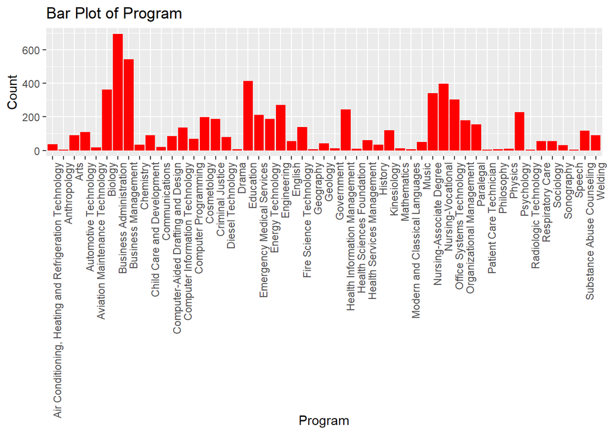

```r
# Program
ggplot(data, aes(x = Program)) +
  geom_bar(fill = "red") +
  theme(axis.text.x = element_text(angle = 90, hjust = 1)) +
  labs(title = "Bar Plot of Program", x = "Program", y = "Count")
```

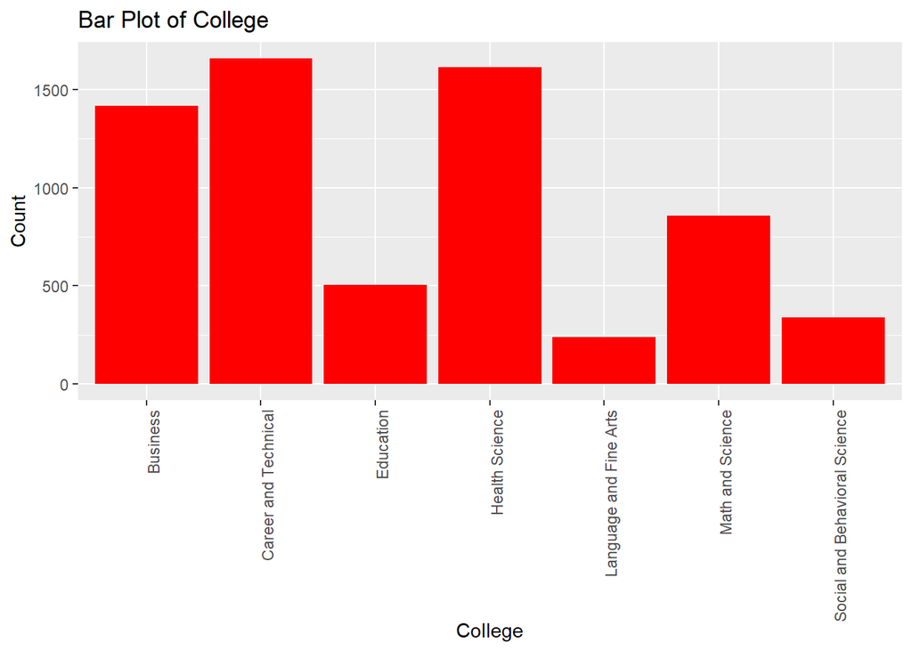

```r
# College
ggplot(data, aes(x = College)) +
  geom_bar(fill = "red") +
  theme(axis.text.x = element_text(angle = 90, hjust = 1)) +
  labs(title = "Bar Plot of College", x = "College", y = "Count")
```

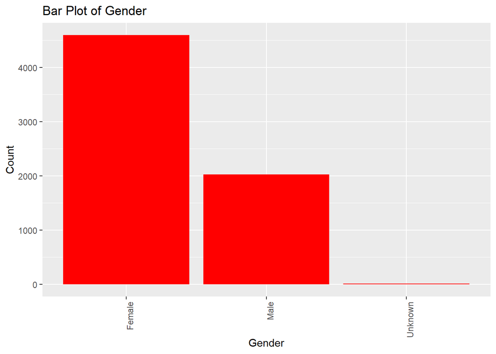

```r
# Gender
ggplot(data, aes(x = Gender)) +
  geom_bar(fill = "red") +
  theme(axis.text.x = element_text(angle = 90, hjust = 1)) +
  labs(title = "Bar Plot of Gender", x = "Gender", y = "Count")
```

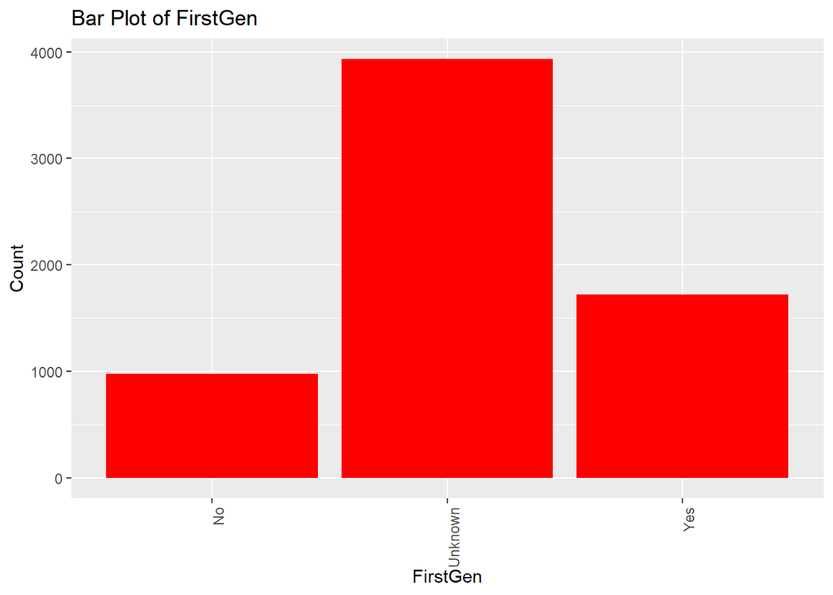

```r
# FirstGen
ggplot(data, aes(x = FirstGen)) +
  geom_bar(fill = "red") +
  theme(axis.text.x = element_text(angle = 90, hjust = 1)) +
  labs(title = "Bar Plot of FirstGen", x = "FirstGen", y = "Count")
```

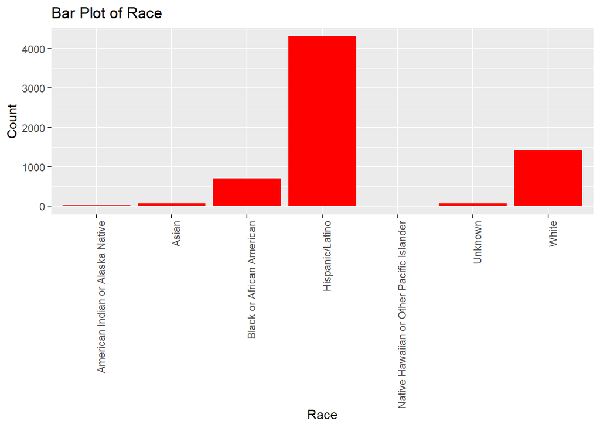

```r
# Race
ggplot(data, aes(x = Race)) +
  geom_bar(fill = "red") +
  theme(axis.text.x = element_text(angle = 90, hjust = 1)) +
  labs(title = "Bar Plot of Race", x = "Race", y = "Count")
```

[figure not shown]

```r
# TSI_MATH
ggplot(data, aes(x = TSI_MATH)) +
  geom_density(fill = "orange") +
  labs(title = "Density Plot of TSI_MATH", x = "TSI_MATH", y = "Density")
```

[figure not shown]

```r
# TSI_WRITING
ggplot(data, aes(x = TSI_WRITING)) +
  geom_density(fill = "orange") +
  labs(title = "Density Plot of TSI_WRITING", x = "TSI_WRITING", y = "Density")
```

[figure not shown]

```r
# TSI_READING
ggplot(data, aes(x = TSI_READING)) +
  geom_density(fill = "orange") +
  labs(title = "Density Plot of TSI_READING", x = "TSI_READING", y = "Density")
```

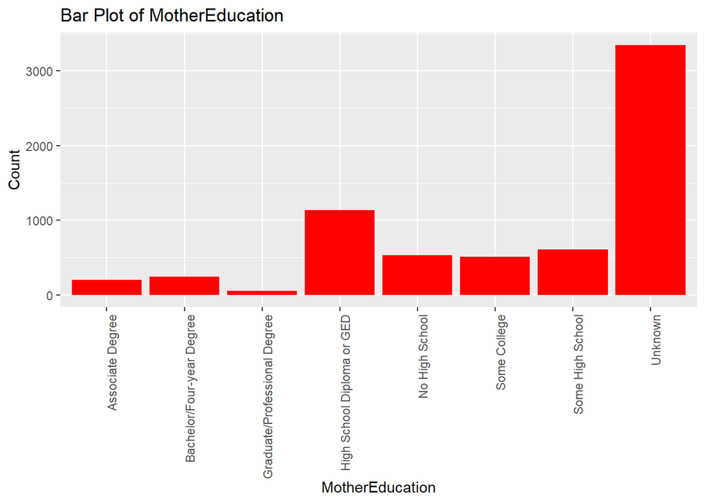

```r
# MotherEducation
ggplot(data, aes(x = MotherEducation)) +
  geom_bar(fill = "red") +
  theme(axis.text.x = element_text(angle = 90, hjust = 1)) +
  labs(title = "Bar Plot of MotherEducation", x = "MotherEducation", y = "Count")
```

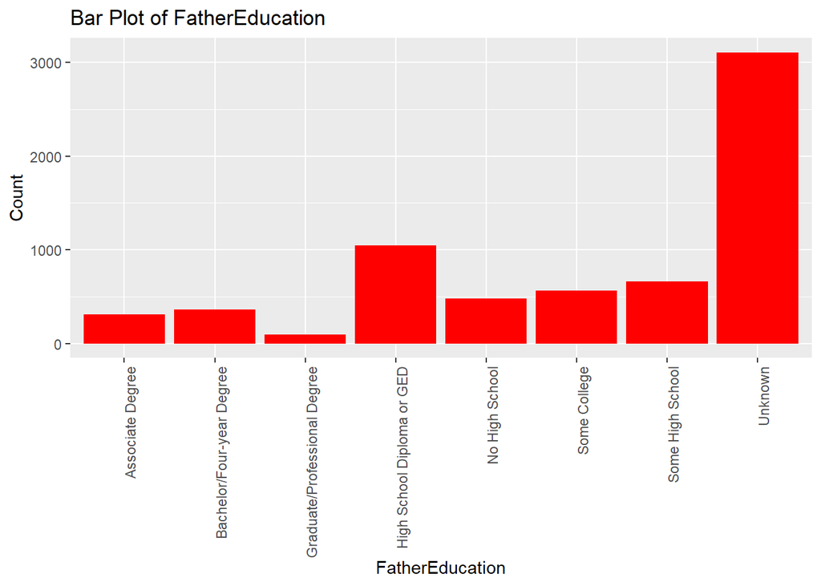

```r
# FatherEducation
ggplot(data, aes(x = FatherEducation)) +
  geom_bar(fill = "red") +
  theme(axis.text.x = element_text(angle = 90, hjust = 1)) +
  labs(title = "Bar Plot of FatherEducation", x = "FatherEducation", y = "Count")
```

[output not shown]

[figure not shown]

```r
# Highschool
ggplot(data, aes(x = Highschool)) +
  geom_density(fill = "orange") +
  labs(title = "Density Plot of Highschool", x = "Highschool", y = "Density")
```

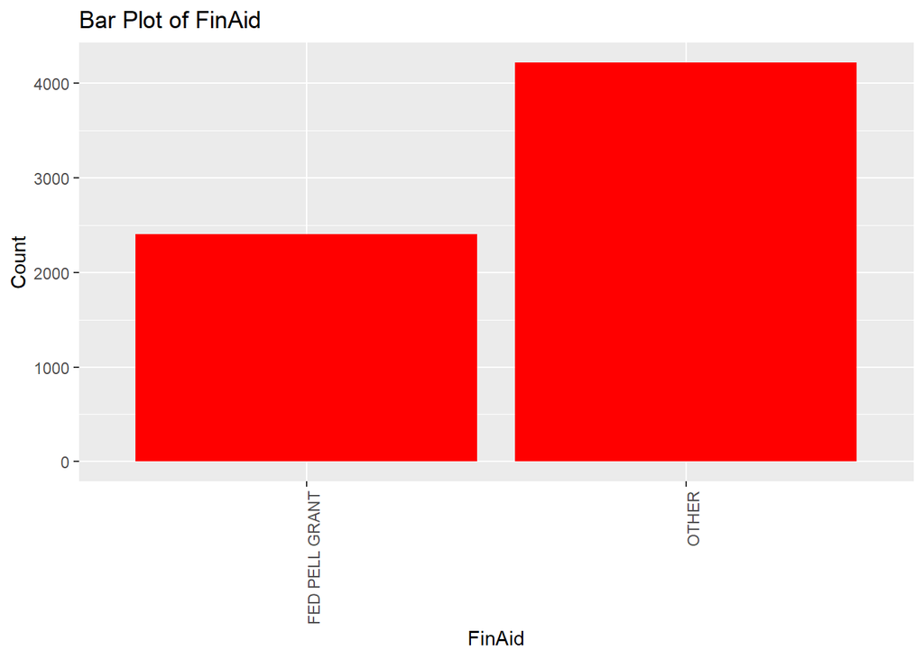

```r
# FinAid
ggplot(data, aes(x = FinAid)) +
  geom_bar(fill = "red") +
  theme(axis.text.x = element_text(angle = 90, hjust = 1)) +
  labs(title = "Bar Plot of FinAid", x = "FinAid", y = "Count")
```

[output not shown]

[output cut: 68 more lines]

[output not shown]

[output not shown]

[output cut: 316 more lines]

[output not shown]

[figure not shown]

```r
# EFC
ggplot(data, aes(x = EFC)) +
  geom_density(fill = "orange") +
  labs(title = "Density Plot of EFC", x = "EFC", y = "Density")
```

The following variables are High Cardinality Variables since they contain a large amount of distinct values. Top n frequent values helps to better visualize these.

```r
# Function to display top n frequent values
top_n_frequent <- function(data, variable, n = 10) {
  freq <- as.data.frame(table(data[[variable]]))
  names(freq) <- c("Value", "Frequency")
  freq <- freq[order(-freq$Frequency), ]
  head(freq, n)
}
# TSI_MATH
top_n_frequent(data, "TSI_MATH")
```

|  | Value | Frequency |
| --- | --- | --- |
| 116 | 350 | 227 |
| 118 | 352 | 220 |
| 226 | NULL | 216 |
| 72 | 310 | 185 |
| 117 | 351 | 178 |
| 119 | 353 | 166 |
| 120 | 354 | 150 |
| 101 | 337 | 148 |
| 110 | 345 | 138 |
| 112 | 347 | 128 |

```r
# TSI_WRITING
top_n_frequent(data, "TSI_WRITING")
```

|  | Value | Frequency |
| --- | --- | --- |
| 171 | NULL | 523 |
| 11 | 240 | 431 |
| 56 | 360 | 206 |
| 51 | 356 | 190 |
| 53 | 358 | 174 |
| 49 | 354 | 167 |
| 50 | 355 | 158 |
| 58 | 362 | 157 |
| 52 | 357 | 150 |
| 59 | 363 | 149 |

```r
# TSI_READING
top_n_frequent(data, "TSI_READING")
```

|  | Value | Frequency |
| --- | --- | --- |
| 208 | NULL | 526 |
| 93 | 352 | 213 |
| 100 | 359 | 192 |
| 89 | 348 | 189 |
| 95 | 354 | 188 |
| 96 | 355 | 184 |
| 94 | 353 | 181 |
| 97 | 356 | 178 |
| 92 | 351 | 175 |
| 98 | 357 | 146 |

```r
# Highschool
top_n_frequent(data, "Highschool")
```

|  | Value | Frequency |
| --- | --- | --- |
| 89 | Midland High School | 1741 |
| 91 | MISD- LHS | 1706 |
| 148 | Texas Ged | 498 |
| 47 | FORT STOCKTON HIGH SCHOOL | 453 |
| 157 | VIOLA M COLEMAN HIGH SCHOOL | 205 |
| 155 | Unknown International High School | 190 |
| 58 | GREENWOOD HIGH SCHOOL | 157 |
| 40 | EARLY COLLEGE HS @ MIDLAND COL | 155 |
| 144 | STANTON HIGH SCHOOL | 94 |
| 126 | RICHARD MILBURN ACADEMY | 81 |

```r
# EFC
top_n_frequent(data, "EFC")
```

|  | Value | Frequency |
| --- | --- | --- |
| 1 | 0 | 2915 |
| 759 | 9999999 | 1099 |
| 482 | 420 | 18 |
| 11 | 10432 | 16 |
| 165 | 1615 | 16 |
| 171 | 1644 | 16 |
| 461 | 40 | 16 |
| 574 | 5545 | 16 |
| 734 | 925 | 16 |
| 239 | 2 | 15 |

### Observations

- There is a very small amount of students that have been Homeschooled. HasGED is very similar, although there are more ‘Yes’ values.
- There are missing values, labeled as “Unknown” for some of the features. The variables that have a high “Unknown” value are FirstGen, MotherEducation, FatherEducation.
- The following variables have a high amount of NULL values - TSI_MATH, TSI_WRITING, TSI_READING

### Data cleaning and preparation

We can assume that NULLS for TSI exams represent students that have not taken the exam. We can replace NULL with 0.

```r
# Replace "NULL" with 0 for TSI variables
data$TSI_MATH[data$TSI_MATH == "NULL"] <- 0
data$TSI_WRITING[data$TSI_WRITING == "NULL"] <- 0
data$TSI_READING[data$TSI_READING == "NULL"] <- 0
```

```r
# TSI_MATH
top_n_frequent(data, "TSI_MATH")
```

|  | Value | Frequency |
| --- | --- | --- |
| 117 | 350 | 227 |
| 119 | 352 | 220 |
| 1 | 0 | 216 |
| 73 | 310 | 185 |
| 118 | 351 | 178 |
| 120 | 353 | 166 |
| 121 | 354 | 150 |
| 102 | 337 | 148 |
| 111 | 345 | 138 |
| 113 | 347 | 128 |

```r
# TSI_WRITING
top_n_frequent(data, "TSI_WRITING")
```

|  | Value | Frequency |
| --- | --- | --- |
| 1 | 0 | 523 |
| 12 | 240 | 431 |
| 57 | 360 | 206 |
| 52 | 356 | 190 |
| 54 | 358 | 174 |
| 50 | 354 | 167 |
| 51 | 355 | 158 |
| 59 | 362 | 157 |
| 53 | 357 | 150 |
| 60 | 363 | 149 |

```r
# TSI_READING
top_n_frequent(data, "TSI_READING")
```

|  | Value | Frequency |
| --- | --- | --- |
| 1 | 0 | 526 |
| 94 | 352 | 213 |
| 101 | 359 | 192 |
| 90 | 348 | 189 |
| 96 | 354 | 188 |
| 97 | 355 | 184 |
| 95 | 353 | 181 |
| 98 | 356 | 178 |
| 93 | 351 | 175 |
| 99 | 357 | 146 |

```r
# Function to convert values based on the specified condition
convert_to_binary <- function(x) {
  as.integer(x < 350 | (x > 400 & x < 950))
}

# Apply the function to the specified columns
data$TSI_MATH <- convert_to_binary(as.numeric(data$TSI_MATH))
data$TSI_WRITING <- convert_to_binary(as.numeric(data$TSI_WRITING))
data$TSI_READING <- convert_to_binary(as.numeric(data$TSI_READING))
```

```r
# TSI_MATH
top_n_frequent(data, "TSI_MATH")
```

|  | Value | Frequency |
| --- | --- | --- |
| 2 | 1 | 4870 |
| 1 | 0 | 1757 |

```r
# TSI_WRITING
top_n_frequent(data, "TSI_WRITING")
```

|  | Value | Frequency |
| --- | --- | --- |
| 2 | 1 | 3450 |
| 1 | 0 | 3177 |

```r
# TSI_READING
top_n_frequent(data, "TSI_READING")
```

|  | Value | Frequency |
| --- | --- | --- |
| 2 | 1 | 3861 |
| 1 | 0 | 2766 |

```r
library(dplyr)
library(tidyr)

# Converting ordinal variables to numeric
data <- data %>%
  mutate(
    MotherEducation = case_when(
      MotherEducation == "Associate Degree" ~ 1,
      MotherEducation == "Bachelor/Four-year Degree" ~ 2,
      MotherEducation == "Graduate/Professional Degree" ~ 3,
      MotherEducation == "High School Diploma or GED" ~ 4,
      MotherEducation == "No High School" ~ 5,
      MotherEducation == "Some College" ~ 6,
      MotherEducation == "Some High School" ~ 7,
      MotherEducation == "Unknown" ~ 8
    ),
    FatherEducation = case_when(
      FatherEducation == "Associate Degree" ~ 1,
      FatherEducation == "Bachelor/Four-year Degree" ~ 2,
      FatherEducation == "Graduate/Professional Degree" ~ 3,
      FatherEducation == "High School Diploma or GED" ~ 4,
      FatherEducation == "No High School" ~ 5,
      FatherEducation == "Some College" ~ 6,
      FatherEducation == "Some High School" ~ 7,
      FatherEducation == "Unknown" ~ 8
    ),
    FirstGen = case_when(
      FirstGen == "Unknown" ~ 3,
      FirstGen == "Yes" ~ 1,
      FirstGen == "No" ~ 0
    )
  )

# Handling binary variables
data$Homeschooled <- as.numeric(data$Homeschooled)
data$HasGED <- as.numeric(data$HasGED)

# Since there are many different high schools, we take into account the top 10 and then use a separate "Other" category for the other ones
# Calculate the top 10 most common high schools
top_schools <- data %>%
  count(Highschool, sort = TRUE) %>%
  top_n(10, n) %>%
  pull(Highschool)

# Replace less common high schools with 'Other'
data <- data %>%
  mutate(Highschool = ifelse(Highschool %in% top_schools, Highschool, "Other"))
```

```r
str(data)
```

```
## 'data.frame':    6627 obs. of  16 variables:
##  $ Program        : chr  "Cosmetology" "Substance Abuse Counseling" "Organizational Management" "English" ...
##  $ College        : chr  "Career and Technical" "Health Science" "Business" "Language and Fine Arts" ...
##  $ Age            : int  24 34 34 26 23 25 22 28 31 30 ...
##  $ Gender         : chr  "Female" "Male" "Female" "Female" ...
##  $ FirstGen       : num  3 3 3 1 3 3 1 3 0 1 ...
##  $ Race           : chr  "White" "Hispanic/Latino" "White" "Black or African American" ...
##  $ TSI_MATH       : int  1 1 0 1 1 1 0 1 1 1 ...
##  $ TSI_WRITING    : int  1 1 1 0 0 0 1 1 1 1 ...
##  $ TSI_READING    : int  1 1 1 0 1 1 0 1 1 1 ...
##  $ MotherEducation: num  6 8 4 7 8 8 7 6 4 7 ...
##  $ FatherEducation: num  6 8 6 4 8 8 4 6 1 7 ...
##  $ Homeschooled   : num  0 0 0 0 0 0 0 0 0 0 ...
##  $ HasGED         : num  0 0 0 0 0 0 0 0 0 0 ...
##  $ Highschool     : chr  "MISD- LHS" "Midland High School" "MISD- LHS" "MISD- LHS" ...
##  $ FinAid         : chr  "OTHER" "FED PELL GRANT" "FED PELL GRANT" "FED PELL GRANT" ...
##  $ EFC            : chr  "616" "9999999" "0" "0" ...
```

```r
library(data.table)
library(mltools)
```

```r
# One hot encoding variables
data_dt <- as.data.table(data)
cols_to_encode <- c("Program", "College", "Gender", "Race", "Highschool", "FinAid")
data_dt[, (cols_to_encode) := lapply(.SD, as.factor), .SDcols = cols_to_encode]
data_encoded <- one_hot(data_dt, dropUnusedLevels = TRUE)
data_encoded_df <- as.data.frame(data_encoded)

# Create a list to hold mapping for each categorical variable
mapping_list <- lapply(cols_to_encode, function(col) {
  # Get the unique levels for the categorical variable
  levels <- unique(data_dt[[col]])

  # Ensure consistent column names across all data frames
  mapping_df <- data.frame(
    original_value = levels,
    encoded_column = paste0(col, "_", as.character(levels))
  )

  return(mapping_df)
})

# Combine all the mappings into a single data frame
mapping_table <- do.call(rbind, mapping_list)
```

```r
# Find the median of the EFC values excluding the non-numeric entries
good_numeric_efc <- as.numeric(data$EFC[grepl("^[0-9]+$", data$EFC)])
median_efc <- median(good_numeric_efc, na.rm = TRUE)

# Replace non-numeric values with NA (to be replaced with the median later)
data$EFC <- as.numeric(data$EFC)
data$EFC[!grepl("^[0-9]+$", data$EFC)] <- NA

# Replace NA values with the median
data$EFC[is.na(data$EFC)] <- median_efc

# Apply the same conversion to the encoded data frame
data_encoded_df$EFC <- as.numeric(data_encoded_df$EFC)
data_encoded_df$EFC[is.na(data_encoded_df$EFC)] <- median_efc
```

```r
str(data_encoded_df)
```

```
## 'data.frame':    6627 obs. of  91 variables:
##  $ Program_Air Conditioning, Heating and Refrigeration Technology: int  0 0 0 0 0 0 0 0 0 0 ...
##  $ Program_Anthropology                                          : int  0 0 0 0 0 0 0 0 0 0 ...
##  $ Program_Arts                                                  : int  0 0 0 0 0 0 0 0 0 0 ...
##  $ Program_Automotive Technology                                 : int  0 0 0 0 0 1 0 0 0 0 ...
##  $ Program_Aviation Maintenance Technology                       : int  0 0 0 0 0 0 0 0 0 0 ...
##  $ Program_Biology                                               : int  0 0 0 0 0 0 0 0 0 0 ...
##  $ Program_Business Administration                               : int  0 0 0 0 0 0 0 0 0 0 ...
##  $ Program_Business Management                                   : int  0 0 0 0 0 0 0 0 0 0 ...
##  $ Program_Chemistry                                             : int  0 0 0 0 0 0 0 0 0 0 ...
##  $ Program_Child Care and Development                            : int  0 0 0 0 0 0 0 0 0 0 ...
##  $ Program_Communications                                        : int  0 0 0 0 0 0 0 0 0 0 ...
##  $ Program_Computer-Aided Drafting and Design                    : int  0 0 0 0 0 0 0 0 0 0 ...
##  $ Program_Computer Information Technology                       : int  0 0 0 0 0 0 0 0 0 0 ...
##  $ Program_Computer Programming                                  : int  0 0 0 0 0 0 0 0 0 0 ...
```

[output cut: 77 more lines]

To minimize dimensionality, apply Principal Component Analysis (PCA)

```r
# Standardize the data (giving it a mean of 0 and a standard deviation of 1) by applying scale to the encoded data
data_scaled <- scale(data_encoded_df)

# Perform PCA
pca_result <- prcomp(data_scaled, center = TRUE, scale. = TRUE)

# Examine the summary to determine the number of principal components
summary(pca_result)
```

```
## Importance of components:
##                            PC1     PC2     PC3     PC4     PC5     PC6     PC7
## Standard deviation     1.91596 1.68149 1.56309 1.54468 1.51066 1.47249 1.45566
## Proportion of Variance 0.04034 0.03107 0.02685 0.02622 0.02508 0.02383 0.02329
## Cumulative Proportion  0.04034 0.07141 0.09826 0.12448 0.14956 0.17338 0.19667
##                            PC8     PC9    PC10    PC11    PC12    PC13    PC14
## Standard deviation     1.44883 1.40677 1.34865 1.33772 1.28129 1.23738 1.19927
## Proportion of Variance 0.02307 0.02175 0.01999 0.01966 0.01804 0.01683 0.01581
## Cumulative Proportion  0.21974 0.24148 0.26147 0.28114 0.29918 0.31600 0.33181
##                          PC15    PC16    PC17    PC18    PC19    PC20    PC21
## Standard deviation     1.1682 1.14819 1.12153 1.11004 1.10694 1.08841 1.08286
## Proportion of Variance 0.0150 0.01449 0.01382 0.01354 0.01347 0.01302 0.01289
## Cumulative Proportion  0.3468 0.36129 0.37511 0.38865 0.40212 0.41514 0.42802
##                           PC22    PC23    PC24    PC25    PC26    PC27    PC28
## Standard deviation     1.07214 1.06453 1.05191 1.03977 1.03775 1.03583 1.02830
## Proportion of Variance 0.01263 0.01245 0.01216 0.01188 0.01183 0.01179 0.01162
## Cumulative Proportion  0.44065 0.45311 0.46527 0.47715 0.48898 0.50077 0.51239
##                           PC29    PC30    PC31    PC32   PC33    PC34    PC35
## Standard deviation     1.02493 1.02383 1.02214 1.01740 1.0141 1.01142 1.01061
## Proportion of Variance 0.01154 0.01152 0.01148 0.01137 0.0113 0.01124 0.01122
## Cumulative Proportion  0.52394 0.53545 0.54694 0.55831 0.5696 0.58085 0.59208
##                           PC36   PC37    PC38    PC39    PC40    PC41    PC42
## Standard deviation     1.01022 1.0097 1.00907 1.00861 1.00666 1.00578 1.00529
## Proportion of Variance 0.01121 0.0112 0.01119 0.01118 0.01114 0.01112 0.01111
## Cumulative Proportion  0.60329 0.6145 0.62568 0.63686 0.64800 0.65911 0.67022
##                          PC43    PC44    PC45    PC46    PC47    PC48    PC49
## Standard deviation     1.0048 1.00458 1.00389 1.00345 1.00231 1.00202 1.00170
## Proportion of Variance 0.0111 0.01109 0.01107 0.01107 0.01104 0.01103 0.01103
## Cumulative Proportion  0.6813 0.69241 0.70348 0.71455 0.72558 0.73662 0.74764
##                           PC50    PC51    PC52    PC53   PC54    PC55    PC56
## Standard deviation     1.00108 1.00019 0.99856 0.99271 0.9914 0.98768 0.98145
## Proportion of Variance 0.01101 0.01099 0.01096 0.01083 0.0108 0.01072 0.01058
## Cumulative Proportion  0.75866 0.76965 0.78061 0.79144 0.8022 0.81296 0.82354
##                           PC57   PC58    PC59    PC60    PC61    PC62    PC63
## Standard deviation     0.97851 0.9728 0.96431 0.96178 0.95461 0.94289 0.93741
## Proportion of Variance 0.01052 0.0104 0.01022 0.01017 0.01001 0.00977 0.00966
## Cumulative Proportion  0.83407 0.8445 0.85468 0.86485 0.87486 0.88463 0.89429
##                           PC64    PC65    PC66   PC67    PC68    PC69    PC70
## Standard deviation     0.92924 0.91663 0.90714 0.8998 0.89140 0.87223 0.85513
## Proportion of Variance 0.00949 0.00923 0.00904 0.0089 0.00873 0.00836 0.00804
## Cumulative Proportion  0.90378 0.91301 0.92205 0.9310 0.93968 0.94804 0.95608
##                           PC71    PC72    PC73    PC74    PC75    PC76    PC77
## Standard deviation     0.83637 0.81187 0.78696 0.71840 0.68844 0.58951 0.51929
## Proportion of Variance 0.00769 0.00724 0.00681 0.00567 0.00521 0.00382 0.00296
## Cumulative Proportion  0.96377 0.97101 0.97782 0.98349 0.98870 0.99251 0.99548
##                           PC78    PC79      PC80      PC81      PC82      PC83
## Standard deviation     0.48413 0.42089 9.979e-14 6.972e-14 5.265e-14 4.734e-14
## Proportion of Variance 0.00258 0.00195 0.000e+00 0.000e+00 0.000e+00 0.000e+00
## Cumulative Proportion  0.99805 1.00000 1.000e+00 1.000e+00 1.000e+00 1.000e+00
##                             PC84      PC85      PC86      PC87      PC88
## Standard deviation     4.517e-14 3.704e-14 3.593e-14 2.491e-14 2.008e-14
## Proportion of Variance 0.000e+00 0.000e+00 0.000e+00 0.000e+00 0.000e+00
## Cumulative Proportion  1.000e+00 1.000e+00 1.000e+00 1.000e+00 1.000e+00
##                             PC89      PC90      PC91
## Standard deviation     1.395e-14 1.211e-14 1.705e-15
## Proportion of Variance 0.000e+00 0.000e+00 0.000e+00
## Cumulative Proportion  1.000e+00 1.000e+00 1.000e+00
```

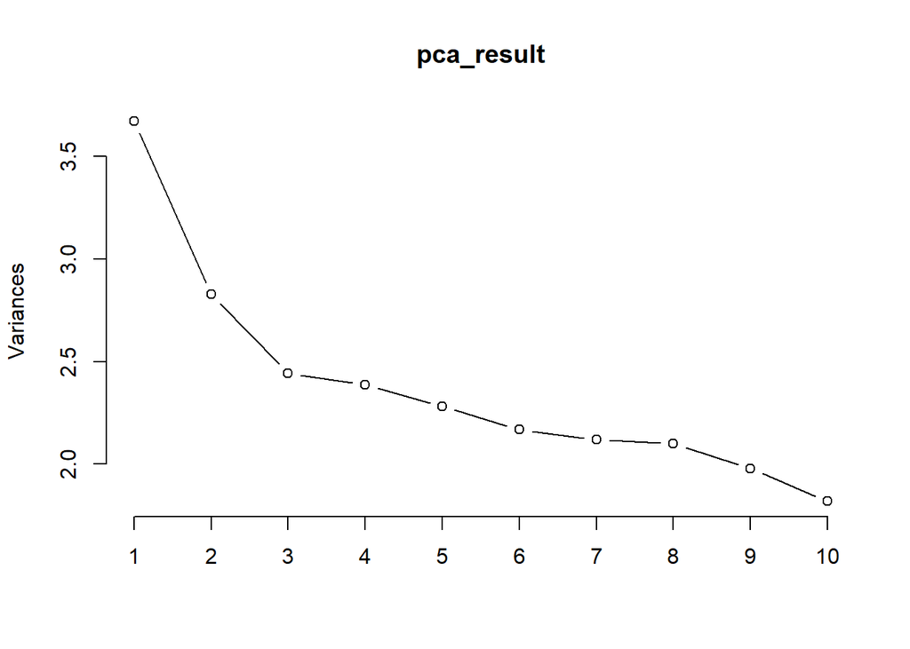

```r
plot(pca_result, type = "lines")
```

Based on these observations, let’s start with the first 5 components for clustering.

```r
# PCA based dataset with the first five components
pca_data <- pca_result$x[, 1:5]
```

Apply K-Means clustering model on PCA reduced data

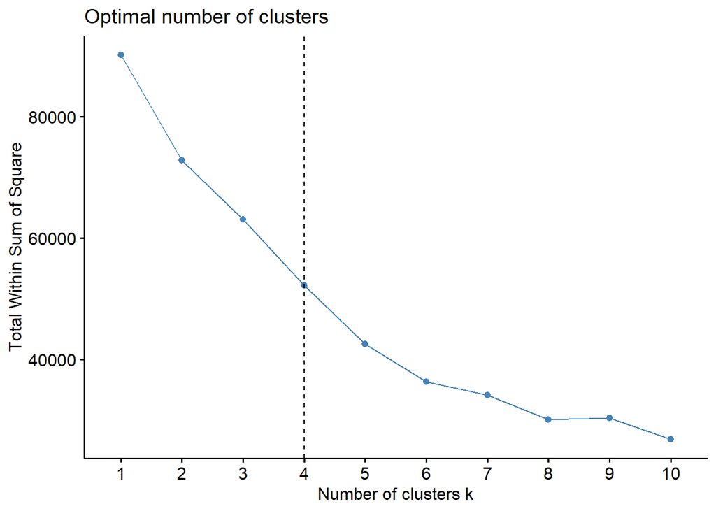

```r
# Determine the number of clusters using the Elbow Method
fviz_nbclust(pca_data, kmeans, method = "wss") + geom_vline(xintercept = 4, linetype = 2)
```

Based on the chart, we’ll start with four clusters.

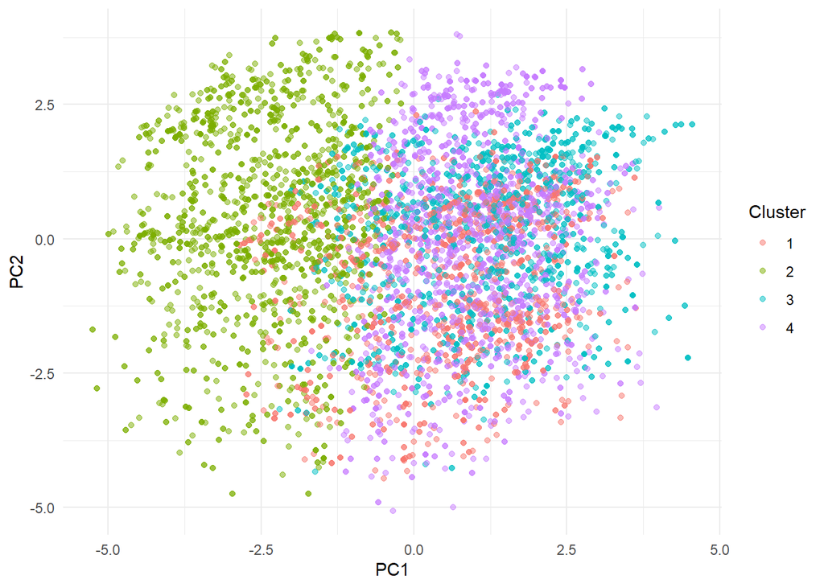

```r
# Convert pca_data to a dataframe
pca_data <- as.data.frame(pca_result$x[, 1:5])

# Properly name the columns to reflect that they are principal components
colnames(pca_data) <- c("PC1", "PC2", "PC3", "PC4", "PC5")

# Perform K-means clustering
set.seed(123)
kmeans_result <- kmeans(pca_data, centers = 4)

# Add the cluster assignments to the PCA data
pca_data$cluster <- kmeans_result$cluster

# Visualize the clusters with a scatter plot for the first two principal components
library(ggplot2)
ggplot(pca_data, aes(PC1, PC2, color = as.factor(cluster))) +
  geom_point(alpha = 0.5) +
  labs(color = 'Cluster') +
  theme_minimal()
```

```r
# Visualize clustering in 3D using the first three principal components
library(rgl)
```

```r
plot3d(pca_data$PC1, pca_data$PC2, pca_data$PC3, col = kmeans_result$cluster)
```

[output not shown]

We now need to interpret the results.

```r
# Define the Mode function
Mode <- function(x) {
  ux <- unique(x)
  ux[which.max(tabulate(match(x, ux)))]
}

# Add cluster assignments to the original data
data$cluster <- kmeans_result$cluster

# Decoding the one-hot encoded variables
decoded_clusters <- lapply(1:max(data$cluster), function(cluster_number) {
  cluster_data <- data[data$cluster == cluster_number, ]
  sapply(cols_to_encode, function(col) {
    # Filter original values that are present in the cluster data
    # original_values <- cluster_data[col]
    # Return the mode of the original values
    Mode(cluster_data[[col]])
  })
})

# Convert the list to a dataframe for easier viewing
decoded_cluster_modes <- do.call(rbind, decoded_clusters)

# Assign column names to match the original categorical variables
colnames(decoded_cluster_modes) <- cols_to_encode

# `decoded_cluster_modes` will give the most frequent original values of the categorical variables for each cluster
print(decoded_cluster_modes)
```

```
##      Program                   College                Gender
## [1,] "Business Administration" "Business"             "Female"
## [2,] "Engineering"             "Career and Technical" "Male"
## [3,] "Nursing-Vocational"      "Health Science"       "Female"
## [4,] "Education"               "Career and Technical" "Female"
##      Race              Highschool  FinAid
## [1,] "Hispanic/Latino" "MISD- LHS" "OTHER"
## [2,] "Hispanic/Latino" "MISD- LHS" "OTHER"
## [3,] "Hispanic/Latino" "Other"     "OTHER"
## [4,] "Hispanic/Latino" "Other"     "OTHER"
```

*Cluster 1:* This cluster is characterized mostly by individuals in the Business Administration program from the Business college. The majority are female and identify as Hispanic/Latino. The most common high school is MISD- LHS, and the financial aid category is ‘OTHER’.

*Cluster 2:* Members of this cluster are predominantly in the Engineering program, associated with the Career and Technical college. They are mostly male and also identify as Hispanic/Latino. Like Cluster 1, the most common high school is MISD- LHS, and the financial aid category is ‘OTHER’.

*Cluster 3:* This cluster primarily consists of individuals in the Nursing-Vocational program from the Health Science college. They are mostly female, identify as Hispanic/Latino, but unlike the first two clusters, the most common high school category is ‘Other’, indicating a more diverse background in terms of high schools. The financial aid category is also ‘OTHER’.

*Cluster 4:* Similar to Cluster 3, this cluster is characterized by individuals predominantly from the Career and Technical college and in the Education program. The majority are female and identify as Hispanic/Latino, with a high school category of ‘Other’, and financial aid category as ‘OTHER’.